# Vignette BIOMASS

# 1 Load BIOMASS and datasets

**Install BIOMASS (to be done once)**

```r
install.packages("BIOMASS")
```

**Load the package**

```r
library(BIOMASS)
require(knitr) # To build tables in this document
```

**Load the two datasets stored in the package**

```r
data(KarnatakaForest)
str(KarnatakaForest)
```

```
## 'data.frame':    61965 obs. of  8 variables:
##  $ plotId : Factor w/ 96 levels "BSP1","BSP10",..: 1 1 1 1 1 1 1 1 1 1 ...
##  $ treeId : Factor w/ 65283 levels "BSP1_001","BSP1_002",..: 1 2 4 5 6 7 8 9 10 11 ...
##  $ family : Factor w/ 81 levels "Acanthaceae",..: 18 61 29 64 6 64 30 29 64 26 ...
##  $ genus  : Factor w/ 256 levels "Acacia","Acrocarpus",..: 233 256 21 134 252 134 9 21 134 82 ...
##  $ species: Factor w/ 320 levels "alata","albiflavescens",..: 28 204 163 32 16 32 161 163 32 189 ...
##  $ D      : num  3.5 3.82 16.87 4.14 5.41 ...
##  $ lat    : num  14.4 14.4 14.4 14.4 14.4 ...
##  $ long   : num  74.9 74.9 74.9 74.9 74.9 ...
```

```r
#
data(NouraguesHD)
str(NouraguesHD)
```

```
## 'data.frame':    1051 obs. of  7 variables:
##  $ plotId : chr  "Plot1" "Plot1" "Plot1" "Plot1" ...
##  $ genus  : chr  "indet" "Qualea" "Dicorynia" "Protium" ...
##  $ species: chr  "indet" "rosea" "guianensis" "cf_guianense" ...
##  $ D      : num  11.5 11.6 83.9 15 36.8 13.5 17.8 17.8 15.9 17.8 ...
##  $ H      : num  12 16 40 18 27 20 24 21 22 24 ...
##  $ lat    : num  4.07 4.07 4.07 4.07 4.07 ...
##  $ long   : num  -52.7 -52.7 -52.7 -52.7 -52.7 ...
```

**Select 10 plots for illustrative purpose**

```r
selecPlot<-KarnatakaForest$plotId%in%c("BSP2","BSP12","BSP14","BSP26","BSP28","BSP30","BSP34","BSP44","BSP63","BSP65")
KarnatakaForestsub<-droplevels(KarnatakaForest[selecPlot,])
```

# 2 Retrieve wood density

## 2.1 Check and retrieve taxonomy

**First, check for any typo in the taxonomy**

```r
Taxo<-correctTaxo(genus=KarnatakaForestsub$genus,species=KarnatakaForestsub$species)
```

```
## [1] "Calling http://taxosaurus.org/retrieve/6970ead9564298d4eae0e6248f500449"
## [1] "Calling http://taxosaurus.org/retrieve/2244196331311416093845e353d2c95a"
## [1] "Calling http://taxosaurus.org/retrieve/e219355b647072a2a2ee633b19321d57"
## [1] "Calling http://taxosaurus.org/retrieve/37b347a99c2baff0431fb685d07efd3b"
## [1] "Calling http://taxosaurus.org/retrieve/585587eedf0a51c441726b36e52e130c"
## [1] "Calling http://taxosaurus.org/retrieve/3c1e332dc577876cb278e23cd5bfd552"
## [1] "Calling http://taxosaurus.org/retrieve/3f9d2b4bf38d4ba9c559066aebaa482b"
```

```r
KarnatakaForestsub$genusCorr<-Taxo$genusCorrected
KarnatakaForestsub$speciesCorr<-Taxo$speciesCorrected
```

**If needed, retrieve APG III families and orders from genus names**

```r
APG<-getTaxonomy(KarnatakaForestsub$genusCorr, findOrder =T)
KarnatakaForestsub$familyAPG<-APG$family
KarnatakaForestsub$orderAPG<-APG$order
```

## 2.2 Wood density

**Retrieve wood density using the plot level average if no genus level information is available**

```r
dataWD<-getWoodDensity(genus=KarnatakaForestsub$genusCorr,
             species=KarnatakaForestsub$speciesCorr,
             stand=KarnatakaForestsub$plotId)
```

```
## The reference dataset contains 16467 wood density values
## Your taxonomic table contains 196 taxa
```

**The same but using the family average and adding other wood density values as references (here invented for the example)**

```r
LocalWoodDensity<-data.frame(genus=c("Ziziphus","Terminalia","Garcinia"),
                             species=c("oenopolia","bellirica","indica"),
                             wd=c(0.65,0.72,0.65))

dataWD<-getWoodDensity(genus=KarnatakaForestsub$genusCorr,
             species=KarnatakaForestsub$speciesCorr,
             family=KarnatakaForestsub$familyAPG,
             stand=KarnatakaForestsub$plotID,
             addWoodDensityData=LocalWoodDensity)
```

```
## The reference dataset contains 16470 wood density values
## Your taxonomic table contains 196 taxa
```

**Below the number of wood density value estimated at the species, genus and plot level:**

```r
# At species level
sum(dataWD$levelWD=="species")
```

```
## [1] 2304
```

```r
# At genus level
sum(dataWD$levelWD=="genus")
```

```
## [1] 2768
```

```r
# At plot level
sum(!dataWD$levelWD%in%c("genus","species"))
```

```
## [1] 370
```

# 3 Build height-diameter models

**You may compare different models at once**

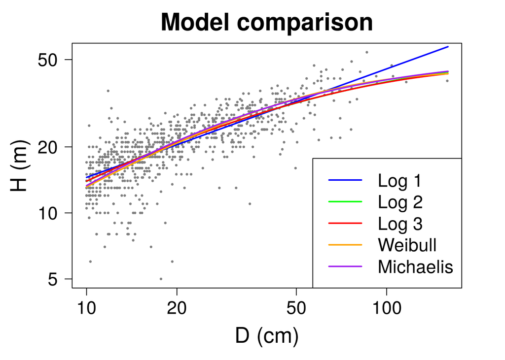

```
Which model would you like to select to model your data ?

##1 : Log 1 (blue)
##----- RSE = 4.1893 (RSElog = 0.2211)
##----- Average bias =  0.0042

##2 : Log 2 (green)
##----- RSE = 4.1017 (RSElog = 0.2194)
----- Average bias =  0.003

3 : Log 3 (red)
----- RSE = 4.1038 (RSElog = 0.2195)
----- Average bias =  0.003

4 : Weibull (orange)
----- RSE =  4.1716
----- Average bias =  0.0052

5 : Michaelis - Menten (purple)
----- RSE =  4.1662
----- Average bias =  0.0148

1: 3
```

```r
HDmodel <- modelHD(D=NouraguesHD$D,
                   H =NouraguesHD$H,
                   drawGraph=TRUE,
                   useWeight=TRUE)
```

**Compute the local H-D model with the lowest RSE**

```r
HDmodel<-modelHD(D=NouraguesHD$D,
                 H=NouraguesHD$H,
                 method="log2",
                 useWeight =TRUE)
```

**Compute models specific to given stands**

```r
HDmodelPerPlot <- by(NouraguesHD,NouraguesHD$plotId,
                     function(x) modelHD(D=x$D,H=x$H, method="weibull",useWeight =T),
                     simplify=FALSE)
RSEmodels<-sapply(HDmodelPerPlot,function(x) x$RSE)
Coeffmodels<-lapply(HDmodelPerPlot,function(x) x$coefficients)
ResHD<-data.frame(Plot=names(unlist(RSEmodels)),
                  a=round(unlist(sapply(Coeffmodels,"[",1)),3),
                  b=round(unlist(sapply(Coeffmodels,"[",2)),3),
                  c=round(unlist(sapply(Coeffmodels,"[",3)),3),
                  RSE=round(unlist(RSEmodels),3))
kable(ResHD, row.names = FALSE)
```

| Plot | a | b | c | RSE |
| --- | --- | --- | --- | --- |
| Plot1 | 43.673 | 29.629 | 0.987 | 4.503 |
| Plot2 | 369.917 | 46732.555 | 0.367 | 3.865 |

# 4 Retrieve height data

**Retrieve height data from a local Height-diameter model** (Note that using a HD model built on French guianan trees for Indian trees is only for illustrative purpose here)

```r
dataHlocal<-retrieveH(D=KarnatakaForestsub$D,
                      model =HDmodel)
```

**Retrieve height data from a Feldpaush et al. (2012) averaged model**

```r
dataHfeld<-retrieveH(D=KarnatakaForestsub$D,
                     region ="SEAsia")
```

**Retrieve height data from Chave et al. (2012) equation 6**

```r
dataHchave<-retrieveH(D=KarnatakaForestsub$D,
                      coord=cbind(KarnatakaForestsub$long,KarnatakaForestsub$lat))
```

# 5 Estimate AGB

**Organize data**

```r
KarnatakaForestsub$WD=dataWD$meanWD
KarnatakaForestsub$H=dataHlocal$H
KarnatakaForestsub$Hfeld=dataHfeld$H
```

**Compute AGB(Mg) per tree**

```r
AGBtree<-computeAGB(D=KarnatakaForestsub$D,
                    WD=KarnatakaForestsub$WD,
                    H =KarnatakaForestsub$H)
```

**Compute AGB(Mg) per plot**

```r
AGBPlotList<-by(KarnatakaForestsub, KarnatakaForestsub$plotId,
                function(x) computeAGB(D=x$D,WD=x$WD,H=x$H),
                simplify=F)
AGBplot<-sapply(AGBPlotList,sum)
```

**Compute AGB(Mg) per tree without height information (Eq. 7 from Chave et al. (2014))**

```r
AGBPlotListChave<-by(KarnatakaForestsub, KarnatakaForestsub$plotId,
                function(x) computeAGB(D=x$D,WD=x$WD,coord =cbind(x$long, x$lat)),
                simplify=F)
AGBplotChave<-sapply(AGBPlotListChave,sum)
```

**Compute AGB(Mg) per tree with Feldpausch et al. (2012) regional H-D model**

```r
AGBPlotListFeld<-by(KarnatakaForestsub, KarnatakaForestsub$plotId,
                function(x) computeAGB(D=x$D,WD=x$WD,H=x$Hfeld),
                simplify=F)
AGBplotFeld<-sapply(AGBPlotListFeld,sum)
```

# 6 Propagate AGB errors

**Organize data**

```r
KarnatakaForestsub$sdWD=dataWD$sdWD
KarnatakaForestsub$HfeldRSE=dataHfeld$RSE
```

**Propagate error for all tree at once using the local HD model constructed above (modelHD), i.e. non-independent allometric errors will be assigned to all trees at each iteration, independently of plots.**

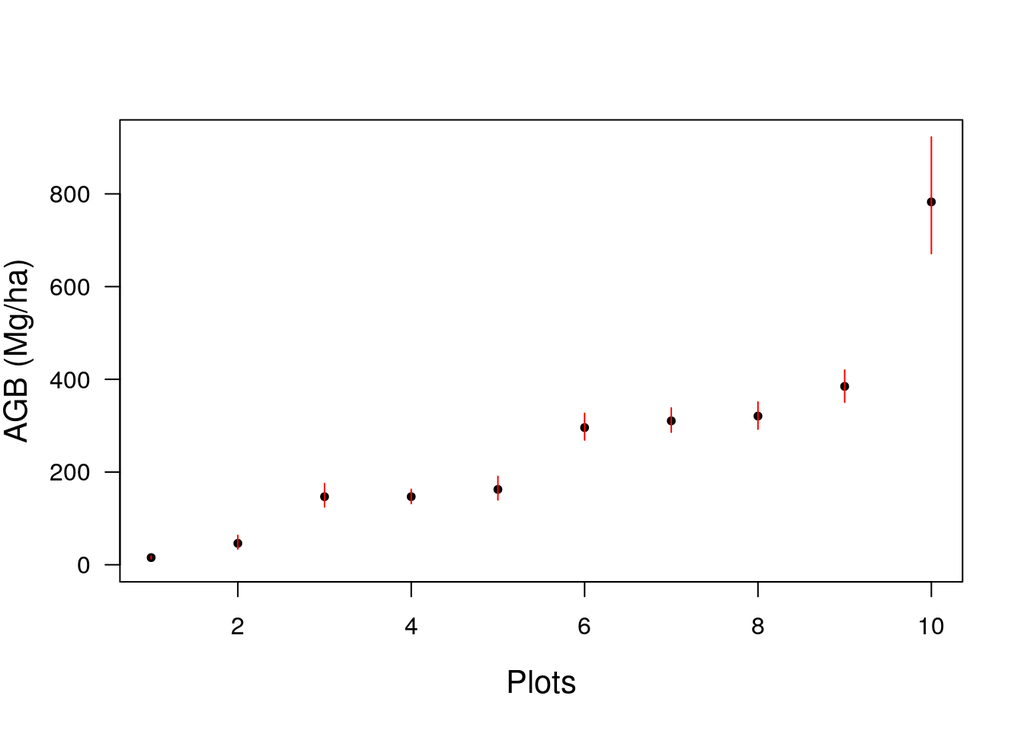

```r
resultMC<-AGBmonteCarlo(D=KarnatakaForestsub$D,WD=KarnatakaForestsub$WD,errWD = KarnatakaForestsub$sdWD,HDmodel=HDmodel,Dpropag ="chave2004")
meanAGBperplot<-by(resultMC$AGB_simu,KarnatakaForestsub$plotId,function(x) mean(apply(x, 2, sum)))
credperplot<-by(resultMC$AGB_simu,KarnatakaForestsub$plotId,function(x) quantile(apply(x,2,sum, na.rm = T), probs = c(0.025, 0.975)))
credinf<-sapply(credperplot,"[",1)
credsup<-sapply(credperplot,"[",2)
ord<-order(meanAGBperplot)
plot(meanAGBperplot[ord],pch=20,xlab="Plots",ylab="AGB (Mg/ha)",ylim=c(0,max(credsup)),las=1,cex.lab=1.3)
segments(1:length(ord),credinf[ord],1:length(ord),credsup[ord],col="red")
```

**Propagate error per plot using the local HD model constructed above (modelHD), i.e. independent allometric errors will be assigned to all trees at each iteration, between plots.**

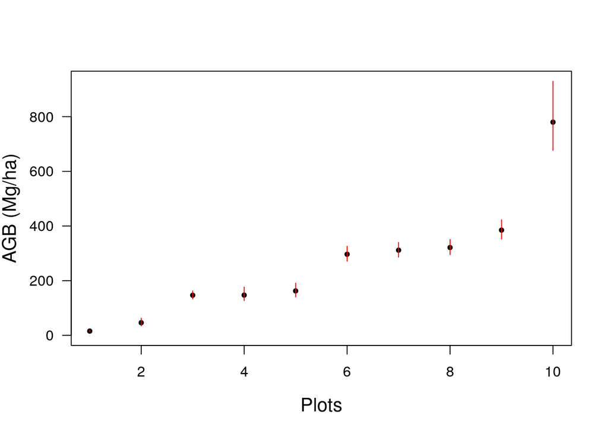

```r
resultMC<-by(KarnatakaForestsub, KarnatakaForestsub$plotId,
             function(x) AGBmonteCarlo(D=x$D,WD=x$WD,H=x$H,errWD = x$sdWD,
                                       HDmodel=HDmodel,Dpropag ="chave2004"),
             simplify=F)
meanAGBperplot<-unlist(sapply(resultMC,"[",1))
credperplot<-sapply(resultMC,"[",4)
credinf<-sapply(credperplot,"[",1)
credsup<-sapply(credperplot,"[",2)
ord<-order(meanAGBperplot)
plot(meanAGBperplot[ord],pch=20,xlab="Plots",ylab="AGB (Mg/ha)",ylim=c(0,max(credsup)),las=1,cex.lab=1.3)
segments(1:length(ord),credinf[ord],1:length(ord),credsup[ord],col="red")
```

**Per plot using the Feldpaush regional HD averaged model (code only given)**

```r
resultMC<-by(KarnatakaForestsub, KarnatakaForestsub$plotId,
             function(x) AGBmonteCarlo(D=x$D,WD=x$WD,errWD=x$sdWD, H=x$Hfeld,
                                       errH=x$HfeldRSE, Dpropag="chave2004"),
             simplify=F)
meanAGBperplot<-unlist(sapply(resultMC,"[",1))
credperplot<-sapply(resultMC,"[",4)
credinf<-sapply(credperplot,"[",1)
credsup<-sapply(credperplot,"[",2)
ord<-order(meanAGBperplot)
plot(meanAGBperplot[ord],pch=20,xlab="Plots",ylab="AGB (Mg/ha)",ylim=c(0,max(credsup)),las=1,cex.lab=1.3)
segments(1:length(ord),credinf[ord],1:length(ord),credsup[ord],col="red")
```

**Per plot using the Chave et al. (2014) Equation 7 (code only given)**

```r
resultMC<-by(KarnatakaForestsub, KarnatakaForestsub$plotId,
             function(x)AGBmonteCarlo(D=x$D,WD=x$WD,errWD=x$sdWD,
                                      coord=cbind(x$long,x$lat),
                                      Dpropag="chave2004"),
             simplify=F)
meanAGBperplot<-unlist(sapply(resultMC,"[",1))
credperplot<-sapply(resultMC,"[",4)
credinf<-sapply(credperplot,"[",1)
credsup<-sapply(credperplot,"[",2)
ord<-order(meanAGBperplot)
plot(meanAGBperplot[ord],pch=20,xlab="Plots",ylab="AGB (Mg/ha)",ylim=c(0,max(credsup)),las=1,cex.lab=1.3)
segments(1:length(ord),credinf[ord],1:length(ord),credsup[ord],col="red")
```

# 7 Some tricks

## 7.1 Mixing measured and estimated height values

If you want to use a mix of directly-measured height and of estimated ones, you may do the following steps.

1 Build a vector of H and RSE where we assume an error of 0.5 m on directly measured trees

```r
NouraguesHD$Hmix<-NouraguesHD$H
NouraguesHD$RSEmix<-0.5
filt<-is.na(NouraguesHD$Hmix)
NouraguesHD$Hmix[filt]<- retrieveH(NouraguesHD$D,model = HDmodel)$H[filt]
NouraguesHD$RSEmix[filt]<-HDmodel$RSE
```

2 Apply the AGBmonteCarlo by setting the height values and their errors (which depend on wether the tree was directly measured or estimated)

```r
resultMC<-by(NouraguesHD, NouraguesHD$plotId,
             function(x)AGBmonteCarlo(D=x$D,WD=x$WD,errWD=x$sdWD,
                                      H=NouraguesHD$Hmix,errH=NouraguesHD$RSEmix,
                                      Dpropag="chave2004"),
             simplify=F)
meanAGBperplot<-unlist(sapply(resultMC,"[",1))
credperplot<-sapply(resultMC,"[",4)
credinf<-sapply(credperplot,"[",1)
credsup<-sapply(credperplot,"[",2)
ord<-order(meanAGBperplot)
plot(meanAGBperplot[ord],pch=20,xlab="Plots",ylab="AGB (Mg/ha)",ylim=c(0,max(credsup)),las=1,cex.lab=1.3)
segments(1:length(ord),credinf[ord],1:length(ord),credsup[ord],col="red")
```

## 7.2 Add your tricks

Please contact Maxime (maxime.rejou@gmail.com) if you would like to add here a code that may be useful for users (code authorship will be respected)